# Homework 01

## Question 1 (Least squares and matrix calculations)

Set the random seed to 43201. Generate $n=100$ observations with $p=5$ predictors according to

$$x_{ij}\overset{\mathrm{iid}}{\sim}N(0,1),
\qquad
\varepsilon_i\overset{\mathrm{iid}}{\sim}N(0,0.7^2),$$

with all predictors and errors generated independently. Let

$$\mathbf X
=
\begin{bmatrix}
\mathbf 1 & \mathbf x_1 & \cdots & \mathbf x_5
\end{bmatrix},
\qquad
\boldsymbol\beta
=
(3,1.4,-0.9,0.7,0,1.1)^{\mathsf T},$$

and generate

$$\mathbf y=\mathbf X\boldsymbol\beta+\boldsymbol\varepsilon.$$

1. Generate the data and report the dimensions and rank of $\mathbf X$. Calculate the least-squares estimate $\widehat{\boldsymbol\beta}$ using a numerically stable least-squares routine, without explicitly calculating $(\mathbf X^{\mathsf T}\mathbf X)^{-1}$. Compare the estimates with the coefficients used to generate the data.

   ```
   (Intercept)          x1          x2          x3          x4          x5
     3.0063210   1.4171604  -0.8883453   0.7952834   0.0484378   1.1319341
   ```

   The dimensions of X has 100 rows and 6 columns. The rank of X is 6. The estimates for the intercept, x1, x2, x3, and x5 are relatively close to the coefficients used to generate the data. However, the estimate for x4 should be closer to 0.
2. Calculate the fitted values, the residual vector $\mathbf r=\mathbf y-\mathbf X\widehat{\boldsymbol\beta}$, and the training root mean squared error

$$\operatorname{RMSE}
=
\left(
\frac{1}{n}\sum_{i=1}^{n}r_i^2
\right)^{1/2}.$$

```r
#Calculate fitted values
##fitted() generates values for the original data
##predicted() generates values for new data
fitted_values <- fitted(model)

#Calculate residual vector r = y - X * beta_hat
residuals <- resid(model)

#Calculate training root mean squared error
training_RMSE <- ((1 / length(fitted_values)) * sum(residuals ^ 2)) ^ (1 / 2)
training_RMSE
```

```
[1] 0.6763696
```

3. Report $\lVert\mathbf X^{\mathsf T}\mathbf r\rVert_\infty$. Explain why this value should be close to zero and what it tells us about the residual vector.

   ```r
   #Report the largest value in the vector by
   ##1. Calculate X^T * r
   ##2. Apply the absolute value
   ##3. Use the max() function to find the largest value
   largest_value <- max(abs(t(X) %*% residuals))
   ```

## Question 2 (Gaussian likelihood for linear regression)

Continue with the data from Question 1. Suppose

$$\mathbf Y\mid\mathbf X
\sim
N_n\left(\mathbf X\boldsymbol\beta,\sigma^2\mathbf I_n\right).$$

The log-likelihood, including the constant term, is

$$\ell(\boldsymbol\beta,\sigma^2)
=
-\frac{n}{2}\log(2\pi\sigma^2)
-\frac{1}{2\sigma^2}
(\mathbf y-\mathbf X\boldsymbol\beta)^{\mathsf T}
(\mathbf y-\mathbf X\boldsymbol\beta).$$

1. For fixed $\sigma^2$, explain why maximizing $\ell(\boldsymbol\beta,\sigma^2)$ over $\boldsymbol\beta$ is equivalent to minimizing the residual sum of squares. What does this imply about the maximum-likelihood estimate of $\boldsymbol\beta$?

   For a fixed standard deviation, maximizing the log-likelihood over beta is equivalent to minimizing the residual sum of squares because the log-likelihood “measures how well a model explains the data” (https://www.geeksforgeeks.org/data-science/log-likelihood/). The second term in the log-likehood formula is the residual sum of squares. Therefore, if the residual sum of squares decreases, then the log-likelihood increases. The maximum-likelihood estimate of beta (coefficients) are the same as the coefficients found under the ordinary least squares method assuming errors are normally distributed (https://rpubs.com/sharmaar_2024/MLE).
2. For fixed $\boldsymbol\beta$, differentiate the log-likelihood with respect to $\sigma^2$ and derive its maximum-likelihood estimate. Calculate this estimate at $\widehat{\boldsymbol\beta}$ and compare it with the unbiased estimate of $\sigma^2$. Explain why the two denominators differ.

   The maximum likelihood estimate at beta_hat is 0.4574759 whereas the unbiased estimate of the variance is 0.4866765. The maximum likelihood estimate is slightly lower than the unbiased estimate. The two denominators differ because the unbiased estimator accounts for the `p` degrees of freedom (https://stats.stackexchange.com/questions/438438/why-is-the-mle-for-variance-in-single-linear-regression-biased).
3. Let

$$\mathbf e_{x_2}=(0,0,1,0,0,0)^{\mathsf T}.$$

Using the variance estimate from part b, plot

$$\ell\left(
\widehat{\boldsymbol\beta}+t\mathbf e_{x_2},
\widehat{\sigma}_{\mathrm{MLE}}^2
\right)$$

over a grid of $t$ values from $-1.25$ to $1.25$. State where the maximum occurs and explain why this agrees with the least-squares result.

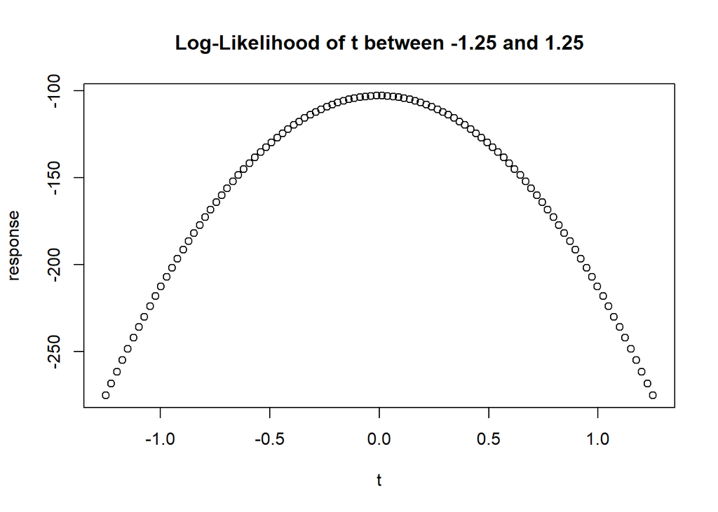

```r
e_x2 <- c(0, 0, 1, 0, 0, 0)

#Generate a range of t values from -1.25 to 1.25
t <- seq(from = -1.25, to = 1.25, length.out = 100)

#Create a function to evaluate the log-likelihood function
log_likelihood <- function(t_value){
  beta_hat2 <- beta_hat + t_value * e_x2
  RSS <- (t((y - X %*% beta_hat2)) %*% (y - X %*% beta_hat2))
  response <- -(n / 2) * log(2 * pi * MLE) - (1 / (2* MLE)) * RSS
  }

#Plug in every t value into the function and solve
response_vector <- c()
for (i in t){
  response <- as.vector(log_likelihood(i))
  response_vector <- append(response_vector, response)
}

#Plot over a grid of t values from -1.25 to 1.25
plot(x = t, y = response_vector,
     main = "Log-Likelihood of t between -1.25 and 1.25",
     ylab = "response")
```

The maximum occurs at t = 0. This agrees with the least-squares result because at t = 0, the term $t\mathbf e_{x_2}$ becomes zero. Therefore,

$$\widehat{\boldsymbol\beta}=\boldsymbol\beta$$

Under constant variance, the log-likelihood expression becomes

$$\ell(\widehat{\boldsymbol\beta},\widehat{\sigma}_{\mathrm{MLE}}^2)
=
-\frac{n}{2}\log(2\pi\widehat{\sigma}_{\mathrm{MLE}}^2)
-\frac{1}{2\widehat{\sigma}_{\mathrm{MLE}}^2}
(\mathbf y-\mathbf X\widehat{\boldsymbol\beta})^{\mathsf T}
(\mathbf y-\mathbf X\widehat{\boldsymbol\beta}).$$

where the rightmost term is the residual sum of squares. When the residual sum of squares decreases, the log-likelihood increases.

## Question 3 (Starting values in nonconvex optimization)

Consider the function

$$f(x)=\exp(1.5x)-3(x+6)^2-0.05x^3,$$

with derivative

$$f'(x)=1.5\exp(1.5x)-6(x+6)-0.15x^2.$$

1. Plot $f(x)$ over the interval $[-40,7]$. Based on the plot, describe the important features of the objective function that may affect numerical optimization.

   Source: https://stackoverflow.com/questions/26091323/how-to-plot-a-function-curve-in-r

[figure not shown]

   ```r
   #BFGS = Broyden-Fletcher-Goldfarb-Shanno
   ##Set method to BFGS in optim() function

   #Define function and its first derivative
   q3_fcn <- function(x){
     exp(1.5 * x) - 3 * (x + 6)^2 - 0.05 * x^3
     }
   q3_first_derive <- function(x){
     1.5 * exp(1.5 * x) - 6 * (x + 6) - 0.15 * x^2
   }

   #Use BFGS to minimize f(x) twice at x = -15 and x = 0
   optimize_15 <- optim(par = -15, fn = q3_fcn, gr = q3_first_derive, method = "BFGS")
   optimize_0 <- optim(par = 0, fn = q3_fcn, gr = q3_first_derive, method = "BFGS")
   ```

   The two runs can converge to different answers because they had different starting points. In the graph above, there could be many local minimums around $x^{(0)}=-15$ and $x^{(0)}=0$ that is not visible to us. The optim() function attempts to locate local minimums, not the global minimum, around the given starting point (https://stackoverflow.com/questions/28546999/why-optimx-in-r-give-different-results-when-changing-the-starting-values). The run where the function optimizes around $x^{(0)}=-15$ gives the lower objective value. Before claiming that $x^{(0)}=-15$ is the global minimum, the optim() function should be run at multiple starting points between -40 and 7.

## Question 4 (Nearly collinear predictors)

Continue with $\mathbf X$ and $\mathbf y$ from Question 1. Set the random seed to 43202 and generate

$$u_i\overset{\mathrm{iid}}{\sim}N(0,1),
\qquad i=1,\ldots,n.$$

Define

$$\mathbf x_6=\mathbf x_1+10^{-4}\mathbf u,
\qquad
\mathbf X_+
=
\begin{bmatrix}
\mathbf X & \mathbf x_6
\end{bmatrix},$$

and let

$$\mathbf y^\star=\mathbf y+10^{-3}\mathbf u.$$

Use a numerically stable least-squares routine throughout.

1. Fit $\mathbf y$ using $\mathbf X$ and $\mathbf X_+$. For each design matrix, report the condition number and training RMSE. For the augmented fit, also report the coefficients of $\mathbf x_1$ and $\mathbf x_6$.

   ```
   Call:
   lm(formula = y ~ x1 + x2 + x3 + x4 + x5, data = data)

   Coefficients:
   (Intercept)           x1           x2           x3           x4           x5
       3.00632      1.41716     -0.88835      0.79528      0.04844      1.13193
   ```

   ```
   Call:
   lm(formula = y ~ x1 + x2 + x3 + x4 + x5 + x6, data = data_plus)

   Coefficients:
   (Intercept)           x1           x2           x3           x4           x5
       3.00167    351.67661     -0.89206      0.79239      0.04865      1.13267
            x6
    -350.25876
   ```

   ```
   Call:
   lm(formula = y_star ~ x1 + x2 + x3 + x4 + x5 + x6, data = data_star)

   Coefficients:
   (Intercept)           x1           x2           x3           x4           x5
       3.00167    341.67661     -0.89206      0.79239      0.04865      1.13267
            x6
    -340.25876
   ```

$$\mathbf y^\star-\mathbf y
=
10(\mathbf x_6-\mathbf x_1)$$

The difference between x<sub>6</sub> and x<sub>1</sub> is 10<sup>-4</sup>u, which is a very small difference. This means that x<sub>6</sub> and x<sub>1</sub> are nearly collinear predictors, which is why the fitted values change very little. This example suggests that it is difficult to interpret separate effects for nearly collinear predictors because “predictors that move together cannot be cleanly separated by the model” (https://metricgate.com/blogs/collinearity-explained-intuitively/).

## Question 5 (Data preparation and summary statistics)

The file `data/data-manipulation.csv` is a small constructed data table containing an observation identifier, a group label, two numeric predictors, and a response. Some response values are missing. For analyses involving the response, use only observations with a recorded response. Do not replace a missing response with zero or a group mean.

1. Read the data and report its dimensions, column types, number of duplicated identifiers, and number of missing values in each column. Create an analysis table containing only observations with a recorded response, and define

$$\texttt{feature\_sum}=\texttt{x1}+\texttt{x2}.$$

```r
#read.csv() reads a .csv file
#dim() determines the dimensions
data_manipulation <- read.csv("data/data-manipulation.csv")

#str() displays the type of an object
str(data_manipulation)
```

```
'data.frame':   24 obs. of  5 variables:
 $ observation_id: chr  "obs-01" "obs-02" "obs-03" "obs-04" ...
 $ group         : chr  "A" "A" "A" "A" ...
 $ x1            : num  1.2 2.4 0.8 3.1 2 1.7 2.8 1 3.5 2.7 ...
 $ x2            : num  2 1.1 2.8 1.5 2.2 1.8 0.9 2.5 1.4 2.3 ...
 $ response      : num  5.36 6.18 4.62 NA 5.52 5.64 7.18 4.7 7.84 7.24 ...
```

```r
#duplicated() finds which elements are duplicated
#Find the number of duplicated identifiers
duplicate_identity <- sum(duplicated(data_manipulation$observation_id))

#Find the number of missing values in EACH column
numNA_obseravtion_id <- sum(is.na(data_manipulation$observation_id))
numNA_group <- sum(is.na(data_manipulation$group))
numNA_x1 <- sum(is.na(data_manipulation$x1))
numNA_x2 <- sum(is.na(data_manipulation$x2))
numNA_response <- sum(is.na(data_manipulation$response))

#Create an analysis table with only recoreded responses
data_manipulation_clean <- na.omit(data_manipulation)

#Define feature_sum
feature_sum <- function(data){
  data$"x1" + data$"x2"
  }
```

The data has 24 rows and 5 columns. The observation_id and group columns are characters whereas the x1, x2, and response columns are numerical. The number of duplicated identifiers is 0. There are no missing values in the observation_id, group, x1, and x2 columns, but there are 3 missing values in the response column.

2. For each group, report the number of observations, the mean response, and the mean of `feature_sum`. State clearly which observations these summaries describe.

   ```
     Observation_Total Mean_Response Mean_Feature_Sum
   A                 7      5.600000         3.600000
   B                 7      7.602857         4.928571
   C                 7      7.997143         6.585714
   ```

3. Sort the analysis table by response from largest to smallest and report the first three rows, including `observation_id`, `group`, `response`, and `feature_sum`. Add code checks verifying that the number of retained rows equals the number of nonmissing responses in the original data, that the analysis table has no missing response values, and that its identifiers are unique.

   ```
      observation_id group  x1  x2 response feature_sum
   22         obs-22     C 5.9 0.7     9.24         6.6
   16         obs-16     B 4.4 0.8     9.00         5.2
   14         obs-14     B 3.8 1.2     8.66         5.0
   ```

   ```
   [1] "The number of retained rows EQUALS the number of nonmissing responses in the original data."
   [1] "The analysis table does NOT have missing values."
   [1] "Its identifieres are unique."
   ```

## Question 6 (Can 39 million Fitbit records represent US adults?)

[Patten et al. (2026)](https://doi.org/10.1038/s41591-026-04352-3) describe Fitbit data from 59,018 participants in the All of Us Research Program. The dataset spans 14 years and contains more than 39 million daily step records. Participants contributed data through one of two routes:

- Bring Your Own Device (BYOD): participants shared data from a Fitbit they already owned.
- Wearables Enhancing All of Us Research (WEAR): invited participants received a Fitbit at no cost.

In the general activity cohort, the BYOD and WEAR groups contained 32,035 and 22,474 participants, respectively. The BYOD value is listed first in each comparison below:

- 77.3% versus 55.1% reported being White;
- 6.1% versus 15.2% reported annual household income between $\$10{,}000$ and $\$25{,}000$; and
- median daily steps were 6,867 versus 5,797.

Suppose the target is the mean of the participant-specific average daily step counts among US adults during the study period, with each adult given equal weight. A researcher writes:

> “This dataset contains more than 39 million daily Fitbit records. Therefore, the average of all recorded step counts should provide an accurate estimate of mean daily activity among US adults.”
1. Are the 39 million daily records independent observations? What characteristics or behaviors could cause some participants to contribute more recorded days than others? Explain how averaging all recorded days would then weight participants unequally.

   The 39 million daily records are independent observations, which means the Fitbit records of one person does not affect the Fitbit records of another person. Some participants may have more recorded days than others due to their job, lifestyle, sudden events, etc. For example, some people may choose to travel with their car, by public transport, by bike, or by walking/running. People with office jobs may have less average step counts than those whose jobs require them to move around more. In addition, sudden events such as car accidents, health conditions, etc., may cause an individual to contribute less recorded days than others. Averaging all recorded days would weigh participants unequally because other factors that contribute to step count, such as lifestyle, careers, and transportation, are not controlled.
2. BYOD participants reported a median of 6,867 daily steps, compared with 5,797 among WEAR participants. Does this comparison show that already owning a Fitbit causes people to walk more? Explain your answer and give at least one plausible alternative explanation based on how participants entered the two groups.

   Correlation is not causation. Already owning a Fitbit may correlate to a higher average daily steps, but it does not mean owning a Fitbit causes higher average daily steps. People who already own a Fitbit may be more likely to be health conscious, so they may have habits or lifestyles that help them stay more active. The BYOD group may already have biases because the group is not randomized. Assuming that invitations to be part of the WEAR group is randomized, participants in the WEAR group come have different habits, lifestyles, careers, etc.
3. A very large dataset can still produce a biased estimate of a population quantity when the people and observations entering the dataset are selected. Using this study, explain how selection of both participants and recorded days could make the observed data differ from the US adult population. Why might the naive average of all recorded daily step counts fail to estimate the stated target? You do not need to determine the direction of the bias.

   The average of all recorded daily step counts fail to estimate the stated target because the groups were not randomly assigned. As stated previously, the BYOD may be more active since they invested into a Fitbit device, so they may have higher average daily steps than the WEAR group. The selection of recorded days could make the observed data differ from the US adult population because people may experience disasters, sudden events, or medical emergencies that may drastically reduce the average daily steps they have.

### Source

Patten, T., Preble, E. A., Master, H., et al. (2026). [The All of Us Research Program’s wearables dataset](https://doi.org/10.1038/s41591-026-04352-3). *Nature Medicine*, 32, 2302-2310.